# Final Project

Shaun Levenson

2025-05-17

**Packages**

```r
options(timeout = 300)
options(java.parameters = "-Xmx8g")
# Install the required packages only if missing and suppress redundant output
packages <- c("h2o","readr","kableExtra","dplyr","ggplot2","knitr","tidyverse","scales","gridExtra","patchwork","e1071","mlbench","tidymodels")
new_packages <- setdiff(packages, rownames(installed.packages()))
if (length(new_packages) > 0) install.packages(new_packages, quietly = TRUE)

# Load the required packages quietly
invisible(lapply(packages, function(pkg) suppressPackageStartupMessages(library(pkg, character.only = TRUE))))

invisible(capture.output(h2o.init()))

cat("Packages used:", packages, "\n")
```

```
## Packages used: h2o readr kableExtra dplyr ggplot2 knitr tidyverse scales gridExtra patchwork e1071 mlbench tidymodels
```

```r
load("F:/ECON/562_Analytics_2/Final Project/bank.Rda")

# Remove the columns that are not needed for the analysis
bank$account <- NULL
bank$dataset <- NULL
bank$demog_genm <- NULL

# Set cat_input1, cat_input2, and demog_genf as factors
bank[] <- lapply(bank, function(x) if(is.character(x)) as.factor(x) else x)
```

# Missing Values, Outliers, and Data Cleaning

```r
# Check for missing values in the dataset
missing_values <- sapply(bank, function(x) sum(is.na(x)))
missing_percentage <- sapply(bank, function(x) sum(is.na(x)) / length(x) * 100)
missing_summary <- data.frame(
  Variable = names(missing_values),
  Missing_Values = missing_values,
  Missing_Percentage = round(missing_percentage, 2)
)

# remove rows with 0 missing values
missing_summary <- missing_summary[missing_summary$Missing_Values > 0, ]
# Sort the summary by missing values
missing_summary <- missing_summary[order(-missing_summary$Missing_Values), ]

# remove row names
rownames(missing_summary) <- NULL

# Display the missing values summary in kable
kable(missing_summary, caption = "Missing Values Summary") %>%
  kable_styling(full_width = FALSE, position = "left") %>%
  column_spec(1, bold = TRUE) %>%
  column_spec(2, color = "blue") %>%
  column_spec(3, color = "red")
```

Missing Values Summary

| Variable | Missing_Values | Missing_Percentage |
| --- | --- | --- |
| int_tgt | 848529 | 80.05 |
| demog_age | 266861 | 25.17 |
| rfm3 | 225786 | 21.30 |
| cnt_tgt | 1 | 0.00 |

```r
# Impute int_tgt missing values with 0
bank$int_tgt[is.na(bank$int_tgt)] <- 0

# Remove rows with missing values for demog_age and rfm3
bank <- bank[!is.na(bank$demog_age) & !is.na(bank$rfm3), ]

# Remove rows with missing values for cnt_tgt
bank <- bank[!is.na(bank$cnt_tgt), ]
```

There are 4 variables with missing values in the dataset. The variables are `int_tgt`, `demog_age`, `rfm3`, and `cnt_tgt`. The percentage of missing values is also shown in the table.

**Missing Removal Reasoning** - `int_tgt`: This variable is only set to `NA` when the customer is did not purchase a product (aka when b_tgt is set = 0). We can impute this with `0` to indicate that they did not spend any money on purchasing a product.

As for `demog_age`, I decided to remove any observations with an age of less than 16. This is because the client is a financial institution and including customers under the age of 16 will not be useful for the analysis due to legal reasons. Additionally, individuals under 16 years old typically do not have financial authority or independence, making them less relevant for the analysis.

```r
# Numerical variable names
numerical_vars <- c("int_tgt", "cnt_tgt", "rfm1", "rfm2", "rfm3", "rfm4",
                    "rfm5", "rfm6", "rfm7", "rfm8", "rfm9", "rfm10",
                    "rfm11", "rfm12", "demog_age", "demog_homeval",
                    "demog_inc", "demog_pr")

# Remove rows with age less than 16
bank <- bank[bank$demog_age >= 16, ]

# Function to compute summary statistics
compute_summary_statistics <- function(bank, numerical_vars) {
  summary_stats <- bank %>%
    dplyr::select(dplyr::all_of(numerical_vars)) %>%
    dplyr::summarise(dplyr::across(
      everything(),
      list(
        mean = ~mean(., na.rm = TRUE),
        sd = ~sd(., na.rm = TRUE),
        median = ~median(., na.rm = TRUE),
        min = ~min(., na.rm = TRUE),
        max = ~max(., na.rm = TRUE),
        skewness = ~e1071::skewness(., na.rm = TRUE)
      ),
      .names = "{col}_{fn}"
    )) %>%
    tidyr::pivot_longer(cols = everything(),
                        names_to = c("Variable", "Statistic"),
                        names_pattern = "(.*)_(.*)",
                        values_to = "Value") %>%
    tidyr::pivot_wider(names_from = Statistic, values_from = Value) %>%
    dplyr::mutate(dplyr::across(where(is.numeric), ~round(.x, 2)))

  return(summary_stats)
}

# Run the function
summary_statistics <- compute_summary_statistics(bank, numerical_vars)

# Display nicely formatted HTML table
summary_statistics %>%
  kable("html", caption = "Summary Statistics for Selected Numerical Variables") %>%
  kable_styling(full_width = TRUE, bootstrap_options = c("striped", "hover")) %>%
  scroll_box(width = "100%", height = "500px")
```

Summary Statistics for Selected Numerical Variables

| Variable | mean | sd | median | min | max | skewness |
| --- | --- | --- | --- | --- | --- | --- |
| int_tgt | 2583.73 | 5931.40 | 0.00 | 0.00 | 200000.0 | 4.77 |
| cnt_tgt | 0.37 | 0.76 | 0.00 | 0.00 | 5.0 | 2.09 |
| rfm1 | 15.44 | 15.09 | 13.98 | 1.15 | 2507.5 | 84.12 |
| rfm2 | 12.80 | 8.93 | 11.10 | 1.58 | 436.0 | 9.92 |
| rfm3 | 15.22 | 11.10 | 14.00 | 0.00 | 600.0 | 9.85 |
| rfm4 | 16.70 | 44.24 | 15.00 | 0.00 | 10000.0 | 205.74 |
| rfm5 | 3.29 | 2.05 | 3.00 | 0.00 | 18.0 | 1.10 |
| rfm6 | 10.34 | 8.78 | 8.00 | 0.00 | 127.0 | 1.77 |
| rfm7 | 2.07 | 1.46 | 2.00 | 0.00 | 11.0 | 1.24 |
| rfm8 | 5.67 | 4.61 | 4.00 | 0.00 | 36.0 | 1.31 |
| rfm9 | 18.18 | 3.87 | 18.00 | 2.00 | 28.0 | -0.73 |
| rfm10 | 13.07 | 4.51 | 13.00 | 0.00 | 60.0 | 2.91 |
| rfm11 | 5.50 | 1.29 | 6.00 | 0.00 | 17.0 | 0.47 |
| rfm12 | 69.32 | 37.36 | 65.00 | 13.00 | 571.0 | 0.30 |
| demog_age | 59.11 | 16.43 | 60.00 | 16.00 | 89.0 | -0.24 |
| demog_homeval | 106619.64 | 92456.21 | 74908.00 | 0.00 | 600067.0 | 2.50 |
| demog_inc | 46562.05 | 25211.91 | 46450.00 | 0.00 | 200007.0 | 0.24 |
| demog_pr | 31.16 | 11.24 | 31.00 | 0.00 | 100.0 | -0.09 |

```r
# List of categorical variable names
categorical_vars <- c("b_tgt", "cat_input1", "cat_input2", "demog_ho", "demog_genf")

# Function to compute frequency tables
compute_frequency_tables <- function(bank, categorical_vars) {
  freq_tables <- lapply(categorical_vars, function(var) {
    bank %>%
      dplyr::select(dplyr::all_of(var)) %>%
      dplyr::filter(!is.na(.data[[var]])) %>%
      dplyr::group_by(.data[[var]]) %>%
      dplyr::summarise(Count = n(), .groups = "drop") %>%
      dplyr::mutate(
        Level = as.character(.data[[var]]),  # Force Level to be character
        Percent = round(100 * Count / sum(Count), 2),
        Variable = var
      ) %>%
      dplyr::select(Variable, Level, Count, Percent)
  })

  # Bind all tables into one
  freq_tables_df <- dplyr::bind_rows(freq_tables)

  return(freq_tables_df)
}

# Run the function
frequency_tables <- compute_frequency_tables(bank, categorical_vars)

# Display nicely formatted HTML table
frequency_tables %>%
  kable("html", caption = "Frequency Tables for Selected Categorical Variables") %>%
  kable_styling(full_width = TRUE, bootstrap_options = c("striped", "hover")) %>%
  scroll_box(width = "100%", height = "500px")
```

Frequency Tables for Selected Categorical Variables

| Variable | Level | Count | Percent |
| --- | --- | --- | --- |
| b_tgt | 0 | 471669 | 76.61 |
| b_tgt | 1 | 144045 | 23.39 |
| cat_input1 | X | 498539 | 80.97 |
| cat_input1 | Y | 37624 | 6.11 |
| cat_input1 | Z | 79551 | 12.92 |
| cat_input2 | A | 110689 | 17.98 |
| cat_input2 | B | 118279 | 19.21 |
| cat_input2 | C | 101607 | 16.50 |
| cat_input2 | D | 71510 | 11.61 |
| cat_input2 | E | 213629 | 34.70 |
| demog_ho | 0 | 206092 | 33.47 |
| demog_ho | 1 | 409622 | 66.53 |
| demog_genf | 0 | 272906 | 44.32 |
| demog_genf | 1 | 342808 | 55.68 |

```r
# transform int_tgt, rfm1, rfm2, rfm3, rfm4, rfm10 using log(x+1) transformation, have the new variables named log_(x)
bank$log_int_tgt <- log(bank$int_tgt + 1)
bank$log_rfm1 <- log(bank$rfm1 + 1)
bank$log_rfm2 <- log(bank$rfm2 + 1)
bank$log_rfm3 <- log(bank$rfm3 + 1)
bank$log_rfm4 <- log(bank$rfm4 + 1)
bank$log_rfm10 <- log(bank$rfm10 + 1)

# Create a new summary statistic data frame with the transformed variables
transformed_vars <- c("log_int_tgt", "log_rfm1", "log_rfm2", "log_rfm3", "log_rfm4", "log_rfm10")
transformed_summary_statistics <- compute_summary_statistics(bank, transformed_vars)
# Display the summary statistics for transformed variables
transformed_summary_statistics %>%
  kable("html", caption = "Summary Statistics for Transformed Variables") %>%
  kable_styling(full_width = TRUE, bootstrap_options = c("striped", "hover")) %>%
  scroll_box(width = "100%", height = "500px")
```

Summary Statistics for Transformed Variables

| Variable | mean | sd | median | min | max | skewness |
| --- | --- | --- | --- | --- | --- | --- |
| log_int_tgt | 2.09 | 3.84 | 0.00 | 0.00 | 12.21 | 1.31 |
| log_rfm1 | 2.67 | 0.48 | 2.71 | 0.77 | 7.83 | 0.25 |
| log_rfm2 | 2.51 | 0.47 | 2.49 | 0.95 | 6.08 | 0.36 |
| log_rfm3 | 2.65 | 0.50 | 2.71 | 0.00 | 6.40 | 0.16 |
| log_rfm4 | 2.71 | 0.54 | 2.77 | 0.00 | 9.21 | -0.30 |
| log_rfm10 | 2.61 | 0.26 | 2.64 | 0.00 | 4.11 | 0.97 |

**Transformation Reasoning** - For each variable that was highly skewed, I applied a log transformation to reduce the skewness and make the distribution more normal. This is important for many machine learning algorithms that assume normally distributed data.

- Additionally, using a log transformation allows for more interpretable coefficients in the models, as they can be interpreted as percentage changes.

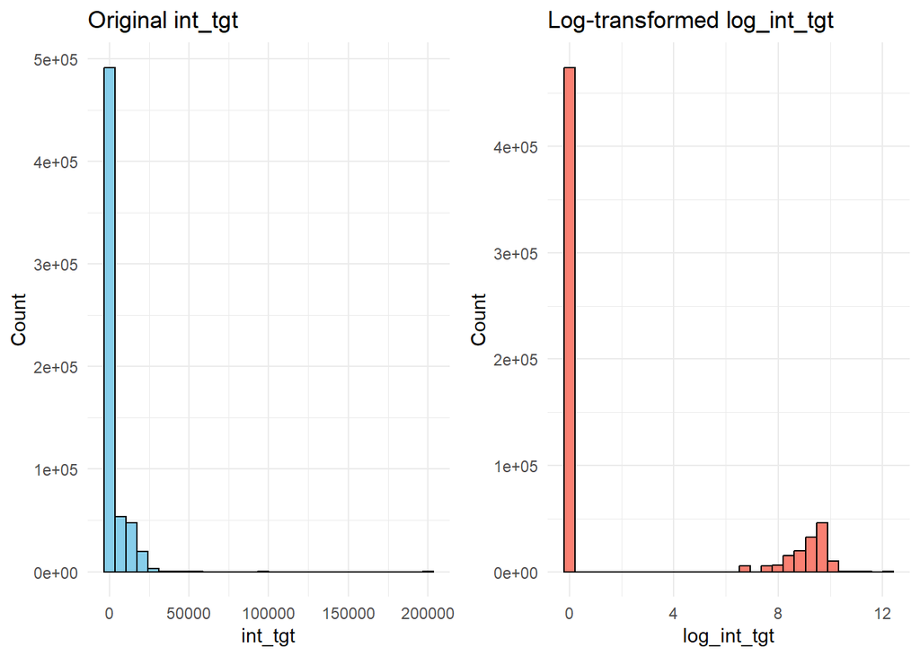

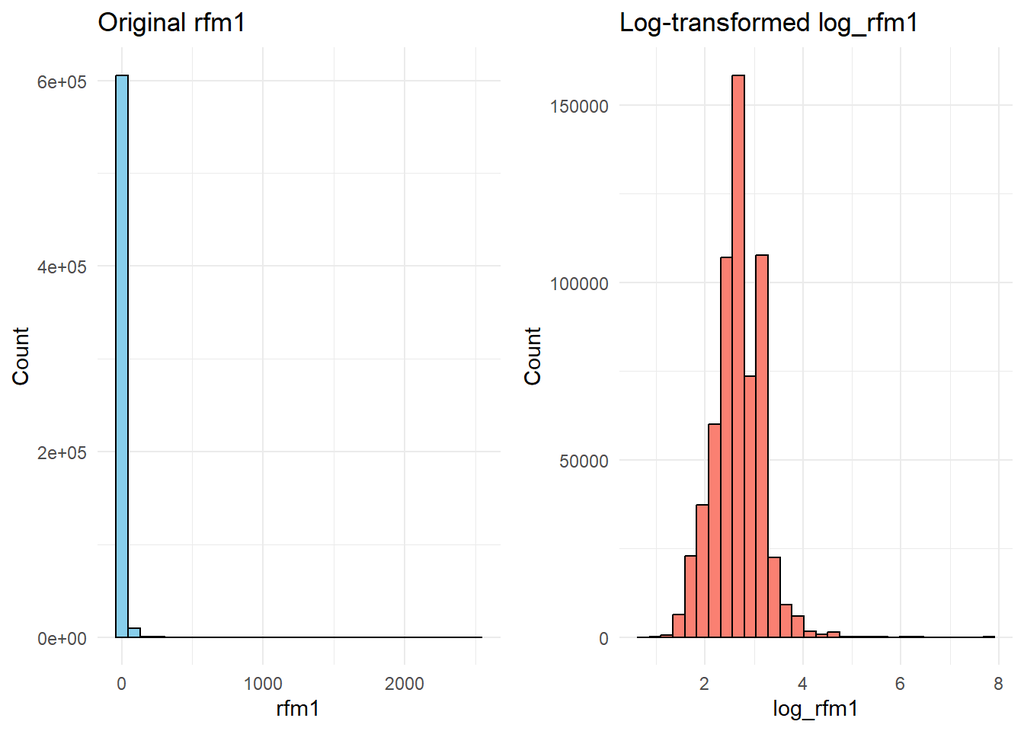

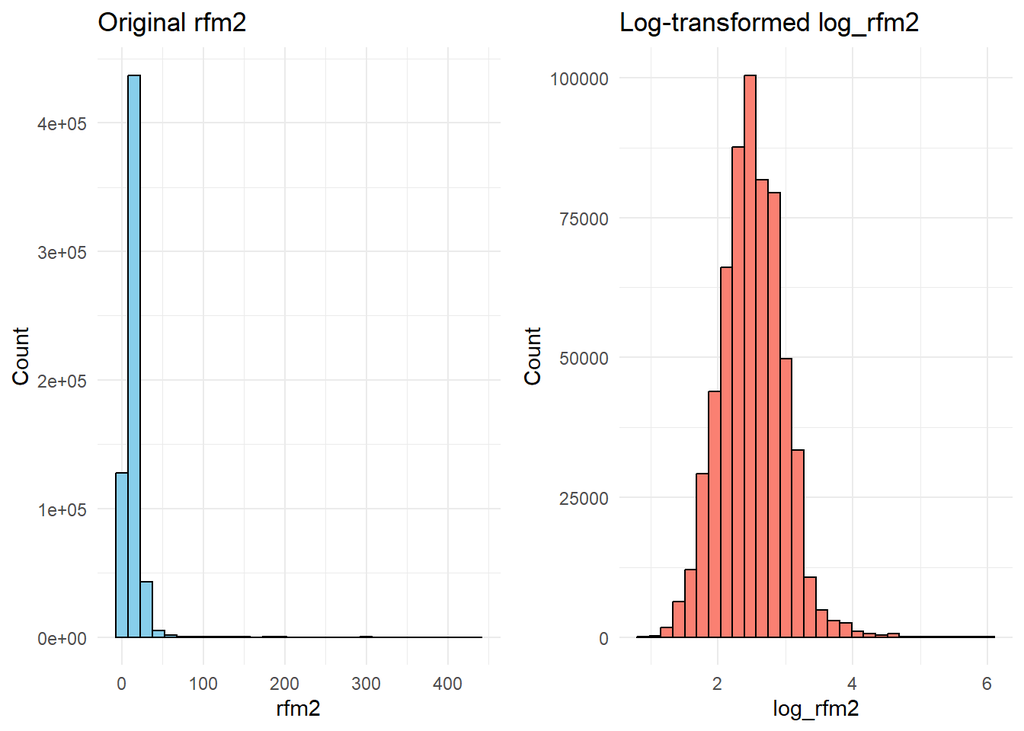

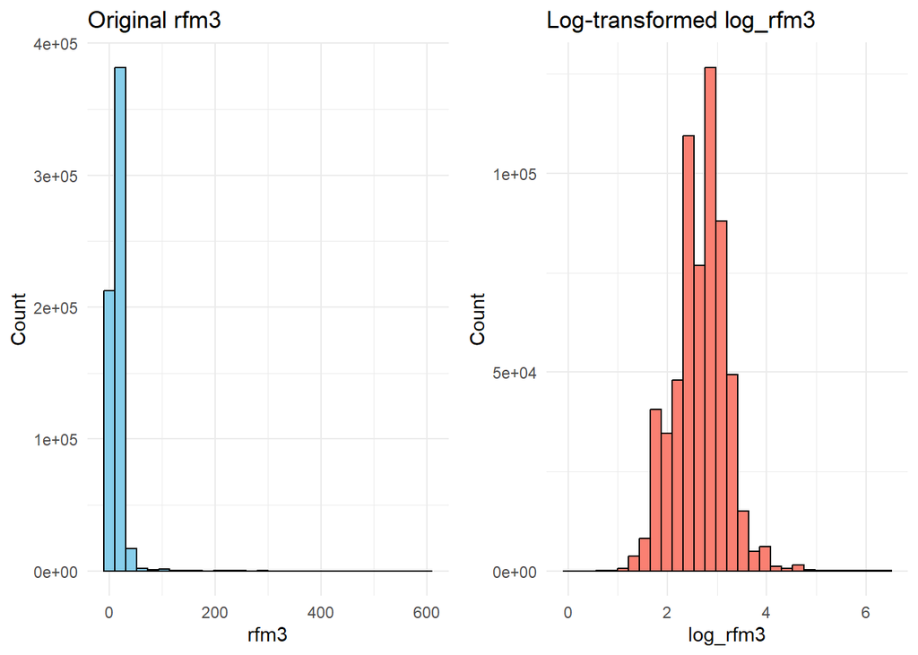

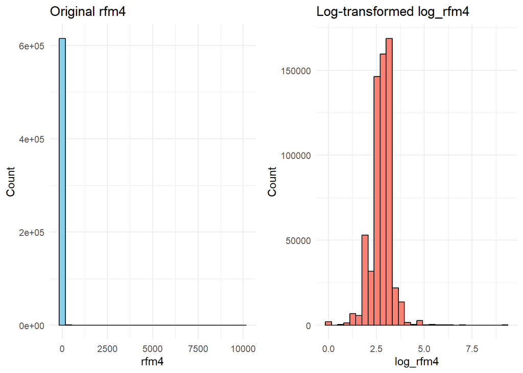

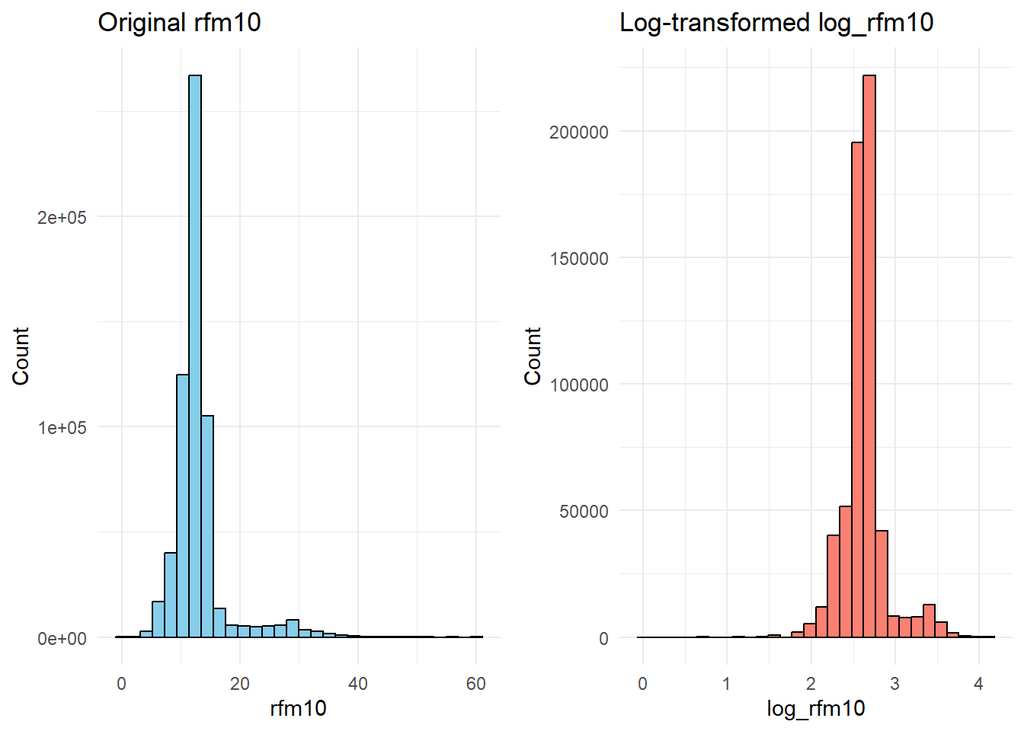

```r
vars <- c("int_tgt", "rfm1", "rfm2", "rfm3", "rfm4", "rfm10")

plot_list <- list()

for (v in vars) {
  p1 <- ggplot(bank, aes_string(x = v)) +
    geom_histogram(bins = 30, fill = "skyblue", color = "black") +
    labs(title = paste("Original", v), x = v, y = "Count") +
    theme_minimal()

  log_var <- paste0("log_", v)
  p2 <- ggplot(bank, aes_string(x = log_var)) +
    geom_histogram(bins = 30, fill = "salmon", color = "black") +
    labs(title = paste("Log-transformed", log_var), x = log_var, y = "Count") +
    theme_minimal()

  # Combine plots side by side
  plot_list[[v]] <- gridExtra::grid.arrange(p1, p2, ncol = 2)
}
```

```r
# To display all plots, just run this:
# This will print each pair of plots one after another
for (p in plot_list) {
  print(p)
}
```

# Interactions

```r
# Create interaction terms
# Income and home value
bank$demog_inc_homeval <- bank$demog_inc * bank$demog_homeval

# Age and home value
bank$demog_age_homeval <- bank$demog_age * bank$demog_homeval

# Age and income
bank$demog_age_inc <- bank$demog_age * bank$demog_inc
```

# Modelling by Target Variable

- `int_tgt`

```r
options(h2o.max_mem_size = "8G")
#Import the dataset
bank_h2o <- as.h2o(bank)
```

```
##   |                                                                              |                                                                      |   0%  |                                                                              |=========================================================…
```

```r
options(timeout = 300)
# Split the data into training, validation, and test sets
splits <- h2o.splitFrame(data = bank_h2o, ratios = c(0.6, 0.2), seed = 123)
train <- splits[[1]]
valid <- splits[[2]]
test <- splits[[3]]
```

```r
# Set the response variable
response <- "log_int_tgt"

# Set the predictor variables
predictors_int <- c(
  "cat_input1", "cat_input2",
  "log_rfm1", "log_rfm2", "log_rfm3", "log_rfm4", "rfm5", "rfm6",
  "rfm7", "rfm8", "rfm9", "log_rfm10", "rfm11", "rfm12",
  "demog_age", "demog_genf", "demog_ho",
  "demog_homeval", "demog_inc", "demog_pr","demog_inc_homeval",
  "demog_age_homeval", "demog_age_inc"
)
```

```r
# Run AutoML with leaderboard on validation frame
automl <- h2o.automl(
  x = predictors_int,
  y = "log_int_tgt",
  training_frame = train,
  validation_frame = valid,
  leaderboard_frame = valid,
  max_runtime_secs = 300,
  seed = 123,
  stopping_rounds = 5,
  stopping_metric = "RMSE",
  nfolds = 0
)
```

```
##   |                                                                              |                                                                      |   0%  |                                                                              |==                                                       …
## 15:50:21.392: AutoML: XGBoost is not available; skipping it.  |                                                                              |==                                                                    |   3%  |                                                                            …
```

```r
# Convert leaderboard to data frame and get model types
leaderboard_df <- as.data.frame(automl@leaderboard)
leaderboard_df$model_id <- as.character(leaderboard_df$model_id)
leaderboard_df$model_type <- sapply(leaderboard_df$model_id, function(id) {
  model <- h2o.getModel(id)
  model@algorithm
})

# Keep only the top 4 unique model types
leaderboard_unique <- leaderboard_df %>%
  distinct(model_type, .keep_all = TRUE) %>%
  slice(1:4)  # just in case fewer than 4

# Get model IDs and types for unique models
top_models <- leaderboard_unique$model_id
top_types <- leaderboard_unique$model_type

# Extract models
models <- lapply(top_models, h2o.getModel)

# --- VALIDATION METRICS (Leaderboard frame) ---
valid_perfs <- lapply(models, function(model) h2o.performance(model, newdata = valid))
valid_rmses <- sapply(valid_perfs, h2o.rmse)
valid_mses <- sapply(valid_perfs, h2o.mse)
valid_r2s <- sapply(valid_perfs, h2o.r2)

# Convert logged RMSE to unlogged scale
valid_unlogged_rmses <- sqrt(exp(valid_rmses^2) - 1)

validation_summary <- data.frame(
  Model = paste("Model", 1:length(top_models)),
  Type = top_types,
  RMSE = round(valid_rmses, 4),
  MSE = round(valid_mses, 4),
  Unlogged_RMSE = round(valid_unlogged_rmses, 2),
  R2 = round(valid_r2s, 4)
)

# Display validation summary table
kable(validation_summary, caption = "Validation Metrics: Top 4 Unique Model Types") %>%
  kable_styling(full_width = FALSE, position = "left") %>%
  column_spec(1, bold = TRUE) %>%
  column_spec(2, color = "purple") %>%
  column_spec(3, color = "blue") %>%
  column_spec(4, color = "red") %>%
  column_spec(5, color = "darkgreen")
```

Validation Metrics: Top 4 Unique Model Types

| Model | Type | RMSE | MSE | Unlogged_RMSE | R2 |
| --- | --- | --- | --- | --- | --- |
| Model 1 | drf | 1.4412 | 2.0770 | 2.64 | 0.8599 |
| Model 2 | gbm | 1.7095 | 2.9224 | 4.19 | 0.8029 |
| Model 3 | deeplearning | 3.1784 | 10.1022 | 156.19 | 0.3188 |
| Model 4 | glm | 3.3184 | 11.0119 | 246.15 | 0.2575 |

```r
# --- TEST METRICS (Only for the top model on leaderboard) ---
final_model <- models[[1]]  # best model based on validation leaderboard

test_perf <- h2o.performance(final_model, newdata = test)
test_rmse <- h2o.rmse(test_perf)
test_mse <- h2o.mse(test_perf)
test_r2 <- h2o.r2(test_perf)
test_unlogged_rmse <- sqrt(exp(test_rmse^2) - 1)

test_summary <- data.frame(
  Model = "Final Model (Model 1)",
  Type = final_model@algorithm,
  RMSE = round(test_rmse, 4),
  MSE = round(test_mse, 4),
  Unlogged_RMSE = round(test_unlogged_rmse, 2),
  R2 = round(test_r2, 4)
)

# Display test summary table
kable(test_summary, caption = "Test Metrics: Final Selected Model") %>%
  kable_styling(full_width = FALSE, position = "left") %>%
  column_spec(1, bold = TRUE) %>%
  column_spec(2, color = "purple") %>%
  column_spec(3, color = "blue") %>%
  column_spec(4, color = "red") %>%
  column_spec(5, color = "darkgreen")
```

Test Metrics: Final Selected Model

| Model | Type | RMSE | MSE | Unlogged_RMSE | R2 |
| --- | --- | --- | --- | --- | --- |
| Final Model (Model 1) | drf | 1.4457 | 2.0902 | 2.66 | 0.8585 |

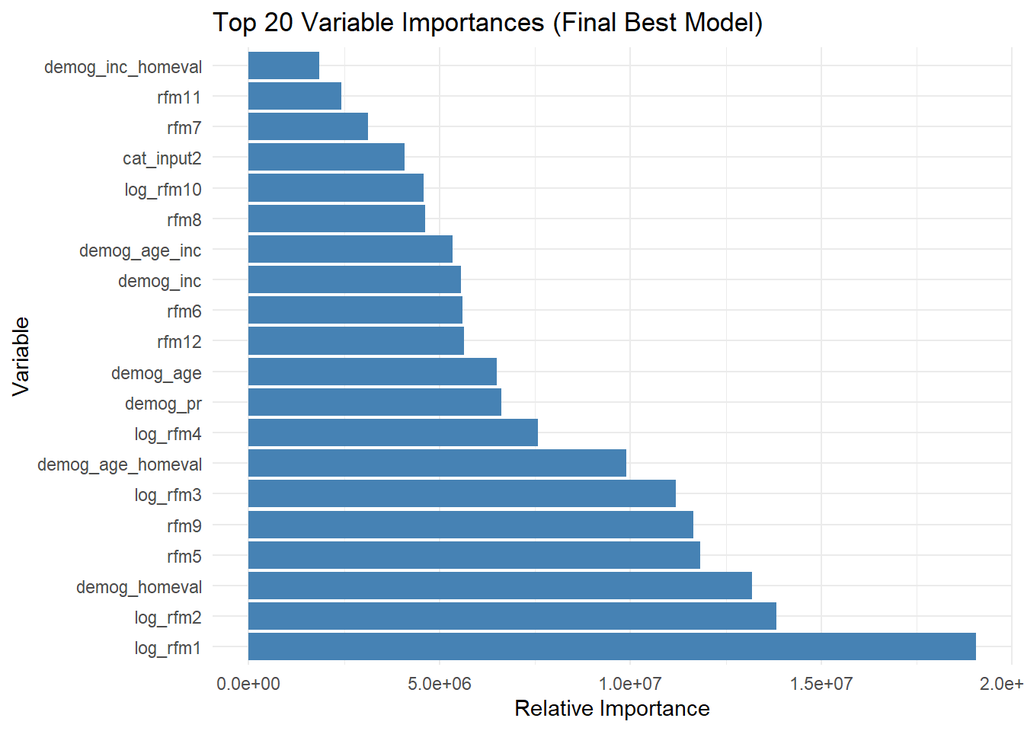

```r
# Variable importance for the final best model (models[[1]])
varimp_df <- as.data.frame(h2o.varimp(models[[1]]))

ggplot(varimp_df[1:20, ], aes(x = reorder(variable, -relative_importance), y = relative_importance)) +
  geom_bar(stat = "identity", fill = "steelblue") +
  coord_flip() +
  labs(title = "Top 20 Variable Importances (Final Best Model)",
       x = "Variable",
       y = "Relative Importance") +
  theme_minimal()
```

```r
# Predictions on test set with final best model
best_model <- models[[1]]
predictions <- h2o.predict(best_model, newdata = test)
```

```
##   |                                                                              |                                                                      |   0%  |                                                                              |=========================================================…
```

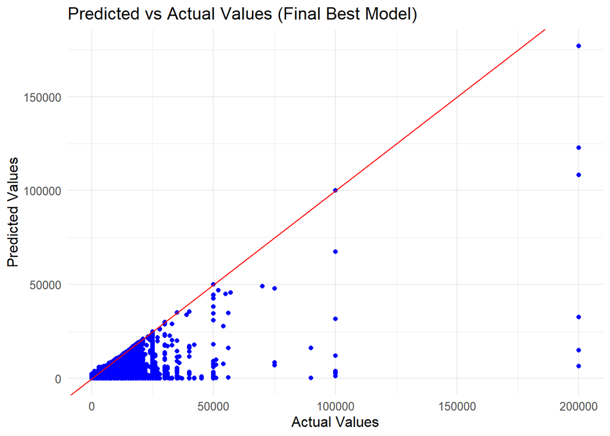

```r
predictions_df <- as.data.frame(predictions)

# Actual values (log-transformed) from test set
actuals_log <- as.data.frame(test[["log_int_tgt"]])
actuals <- exp(actuals_log[[1]])  # back-transform

# Predicted values back-transformed
predicted <- exp(predictions_df[[1]])

# Actual vs Predicted dataframe
pred_vs_actual_df <- data.frame(
  Actual = actuals,
  Predicted = predicted
)

ggplot(pred_vs_actual_df, aes(x = Actual, y = Predicted)) +
  geom_point(color = "blue") +
  geom_abline(slope = 1, intercept = 0, color = "red") +  # perfect prediction line
  labs(title = "Predicted vs Actual Values (Final Best Model)",
       x = "Actual Values",
       y = "Predicted Values") +
  theme_minimal() +
  theme(text = element_text(size = 12))
```

```r
# GLM coefficient table only if the 4th model is a GLM
model_4 <- models[[4]]  # 4th model from the unique top 4 list
if (model_4@algorithm == "glm") {
  coef_table <- model_4@model$coefficients_table
  coef_df <- coef_table[, c("names", "coefficients")]
  coef_df$Odds_Ratio_Percent <- round((exp(coef_df$coefficients) - 1) * 100, 2)
  colnames(coef_df) <- c("Predictor", "Coefficient", "Odds Ratio (%)")

  kable(coef_df, caption = "GLM Coefficients and Odds Ratios (%) for 4th Model") %>%
    kable_styling(full_width = FALSE, position = "left") %>%
    column_spec(1, bold = TRUE) %>%
    column_spec(2, color = "blue") %>%
    column_spec(3, color = "red")

} else {
  cat("The 4th model is not a GLM. It is a", model_4@algorithm, "model.\n")
}
```

GLM Coefficients and Odds Ratios (%) for 4th Model

| Predictor | Coefficient | Odds Ratio (%) |
| --- | --- | --- |
| Intercept | 9.1656809 | 956223.08 |
| cat_input2.A | 0.1102875 | 11.66 |
| cat_input2.B | 0.0886604 | 9.27 |
| cat_input2.C | -0.0050504 | -0.50 |
| cat_input2.D | -0.0575689 | -5.59 |
| cat_input2.E | -0.1377800 | -12.87 |
| cat_input1.X | 0.0404378 | 4.13 |
| cat_input1.Y | -0.0142278 | -1.41 |
| cat_input1.Z | -0.0243132 | -2.40 |
| demog_genf.0 | -0.0134046 | -1.33 |
| demog_genf.1 | 0.0153435 | 1.55 |
| demog_age | -0.0042269 | -0.42 |
| demog_ho | -0.0318255 | -3.13 |
| demog_homeval | 0.0000085 | 0.00 |
| demog_inc | 0.0000022 | 0.00 |
| demog_pr | -0.0011127 | -0.11 |
| rfm5 | 0.4166238 | 51.68 |
| rfm6 | -0.0062728 | -0.63 |
| rfm7 | -0.1152239 | -10.88 |
| rfm8 | 0.0249737 | 2.53 |
| rfm9 | -0.1990148 | -18.05 |
| rfm11 | 0.0126836 | 1.28 |
| rfm12 | 0.0026433 | 0.26 |
| log_rfm1 | -0.9859614 | -62.69 |
| log_rfm2 | -1.1087890 | -67.00 |
| log_rfm3 | 0.1029872 | 10.85 |
| log_rfm4 | -0.0548908 | -5.34 |
| log_rfm10 | -0.1889794 | -17.22 |
| demog_inc_homeval | 0.0000000 | 0.00 |
| demog_age_homeval | 0.0000000 | 0.00 |
| demog_age_inc | 0.0000000 | 0.00 |

- `b_tgt`

```r
# Set the response variable
response_b <- "b_tgt"

# Set the predictor variables
predictors_b <- c(
  "cat_input1", "cat_input2",
  "log_rfm1", "log_rfm2", "log_rfm3", "log_rfm4", "rfm5", "rfm6",
  "rfm7", "rfm8", "rfm9", "log_rfm10", "rfm11", "rfm12",
  "demog_age", "demog_genf", "demog_ho",
  "demog_homeval", "demog_inc", "demog_pr","demog_inc_homeval",
  "demog_age_homeval", "demog_age_inc"
)
```

```r
# Run AutoML with validation leaderboard frame
automl_b <- h2o.automl(
  x = predictors_b,
  y = response_b,
  training_frame = train,
  validation_frame = valid,
  leaderboard_frame = valid,  # validation used for leaderboard
  max_runtime_secs = 300,
  seed = 123,
  stopping_rounds = 5,
  stopping_metric = "AUC",
  nfolds = 0
)
```

```
##   |                                                                              |                                                                      |   0%  |                                                                              |                                                         …
## 15:59:54.283: AutoML: XGBoost is not available; skipping it.  |                                                                              |==                                                                    |   2%  |                                                                            …
```

```r
# Convert leaderboard to data frame and get model types
leaderboard_df_b <- as.data.frame(automl_b@leaderboard)
leaderboard_df_b$model_id <- as.character(leaderboard_df_b$model_id)
leaderboard_df_b$model_type <- sapply(leaderboard_df_b$model_id, function(id) {
  model <- h2o.getModel(id)
  model@algorithm
})

# Keep only the top 4 unique model types (from validation leaderboard)
leaderboard_unique_b <- leaderboard_df_b %>%
  distinct(model_type, .keep_all = TRUE) %>%
  slice(1:4)

top_models_b <- leaderboard_unique_b$model_id
top_types_b <- leaderboard_unique_b$model_type

# Extract the top 4 models
models_b <- lapply(top_models_b, h2o.getModel)

# Validation AUC for top 4 models (from leaderboard)
validation_performances_b <- lapply(models_b, function(model) h2o.performance(model, newdata = valid))
validation_auc_b <- sapply(validation_performances_b, h2o.auc)

# Build validation summary table
validation_summary_b <- data.frame(
  Model = paste("Model", 1:length(top_models_b)),
  Type = top_types_b,
  Validation_AUC = round(validation_auc_b, 4)
)

# Display validation summary table
kable(validation_summary_b, caption = "Top 4 Unique Model Types: Validation Performance Summary for b_tgt") %>%
  kable_styling(full_width = FALSE, position = "left") %>%
  column_spec(1, bold = TRUE) %>%
  column_spec(2, color = "purple") %>%
  column_spec(3, color = "blue")
```

Top 4 Unique Model Types: Validation Performance Summary for b_tgt

| Model | Type | Validation_AUC |
| --- | --- | --- |
| Model 1 | gbm | 0.9970 |
| Model 2 | drf | 0.9961 |
| Model 3 | deeplearning | 0.8664 |
| Model 4 | glm | 0.8521 |

```r
# Now evaluate the best model (models_b[[1]]) on the test set for final performance
test_performance_b <- h2o.performance(models_b[[1]], newdata = test)
test_auc_b <- h2o.auc(test_performance_b)

# Build test summary table for final chosen model
test_summary_b <- data.frame(
  Model = "Best Model (Model 1)",
  Type = top_types_b[1],
  Test_AUC = round(test_auc_b, 4)
)

# Display test performance summary
kable(test_summary_b, caption = "Final Best Model Test Performance for b_tgt") %>%
  kable_styling(full_width = FALSE, position = "left") %>%
  column_spec(1, bold = TRUE) %>%
  column_spec(2, color = "purple") %>%
  column_spec(3, color = "blue")
```

Final Best Model Test Performance for b_tgt

| Model | Type | Test_AUC |
| --- | --- | --- |
| Best Model (Model 1) | gbm | 0.9965 |

```r
# Save the final best model
h2o.saveModel(models_b[[1]], path = "F:/ECON/562_Analytics_2/Final Project/models/model_1_b_tgt", force = TRUE)
```

```
## [1] "F:\\ECON\\562_Analytics_2\\Final Project\\models\\model_1_b_tgt\\GBM_1_AutoML_8_20250517_155954"
```

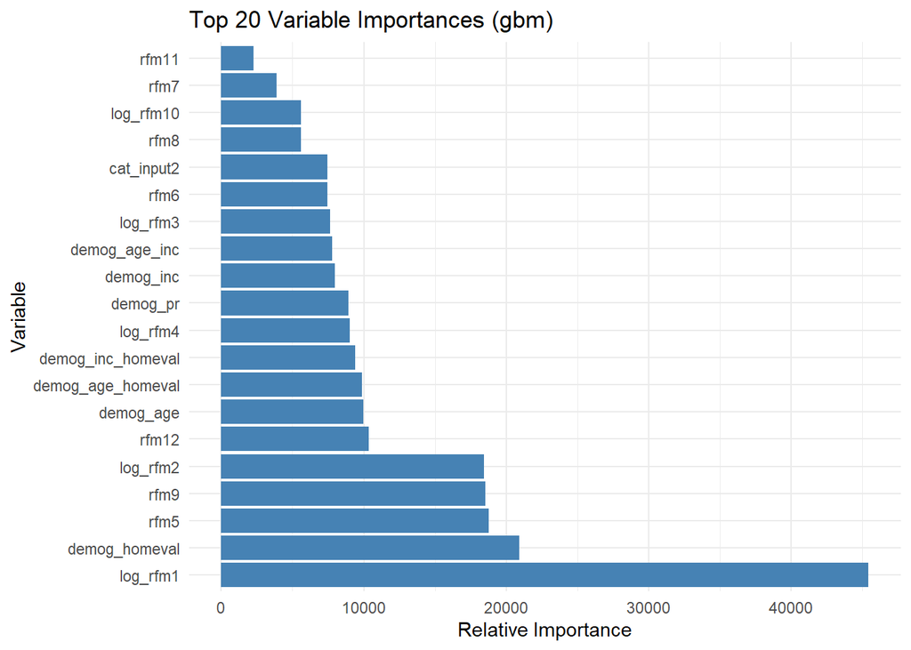

```r
# === Variable Importance for Best Model ===
varimp_df_b <- as.data.frame(h2o.varimp(models_b[[1]]))

# Plot Top 20 Variable Importances
ggplot(varimp_df_b[1:20, ], aes(x = reorder(variable, -relative_importance), y = relative_importance)) +
  geom_bar(stat = "identity", fill = "steelblue") +
  coord_flip() +
  labs(title = paste("Top 20 Variable Importances (", top_types_b[1], ")", sep = ""),
       x = "Variable",
       y = "Relative Importance") +
  theme_minimal()
```

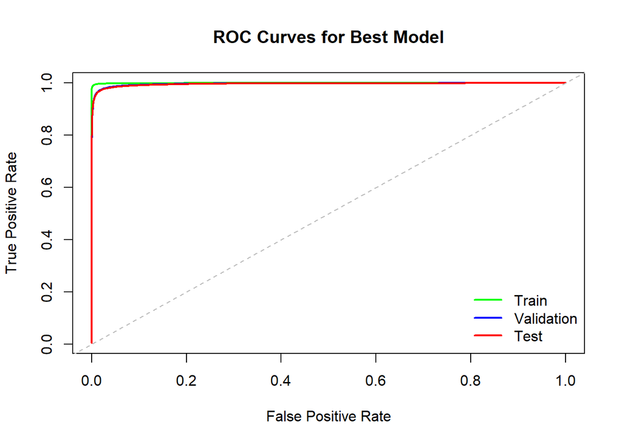

```r
# === ROC / AUC Curves for Best Model ===
perf_train <- h2o.performance(models_b[[1]], newdata = train)
perf_valid <- h2o.performance(models_b[[1]], newdata = valid)
perf_test  <- h2o.performance(models_b[[1]], newdata = test)

# Extract TPR and FPR
roc_train <- as.data.frame(h2o.tpr(perf_train))
roc_train$fpr <- as.data.frame(h2o.fpr(perf_train))$fpr

roc_valid <- as.data.frame(h2o.tpr(perf_valid))
roc_valid$fpr <- as.data.frame(h2o.fpr(perf_valid))$fpr

roc_test <- as.data.frame(h2o.tpr(perf_test))
roc_test$fpr <- as.data.frame(h2o.fpr(perf_test))$fpr

# Plot
plot(roc_train$fpr, roc_train$tpr, type = "l", col = "green", lwd = 2,
     xlab = "False Positive Rate", ylab = "True Positive Rate",
     main = "ROC Curves for Best Model")
lines(roc_valid$fpr, roc_valid$tpr, col = "blue", lwd = 2)
lines(roc_test$fpr, roc_test$tpr, col = "red", lwd = 2)
abline(a = 0, b = 1, lty = 2, col = "gray")  # Diagonal reference

# Add legend
legend("bottomright", legend = c("Train", "Validation", "Test"),
       col = c("green", "blue", "red"), lwd = 2, bty = "n")
```

```r
# === GLM Coefficient Table (4th Model) ===
model_4 <- h2o.getModel(top_models_b[4])

if (model_4@algorithm == "glm") {
  coef_table <- model_4@model$coefficients_table

  coef_df <- coef_table[, c("names", "coefficients")]
  coef_df$`Odds Ratio (%)` <- round((exp(coef_df$coefficients) - 1) * 100, 2)

  colnames(coef_df) <- c("Predictor", "Coefficient", "Odds Ratio (%)")

  kable(coef_df, caption = "GLM Coefficients and Odds Ratios (%)") %>%
    kable_styling(full_width = FALSE, position = "left") %>%
    column_spec(1, bold = TRUE) %>%
    column_spec(2, color = "blue") %>%
    column_spec(3, color = "red")
} else {
  cat("The 4th model is not a GLM. It is a", model_4@algorithm, "model.\n")
}
```

GLM Coefficients and Odds Ratios (%)

| Predictor | Coefficient | Odds Ratio (%) |
| --- | --- | --- |
| Intercept | 5.0998005 | 16298.92 |
| cat_input2.A | 0.1119309 | 11.84 |
| cat_input2.B | 0.0942768 | 9.89 |
| cat_input2.C | -0.0037163 | -0.37 |
| cat_input2.D | -0.0437802 | -4.28 |
| cat_input2.E | -0.1597183 | -14.76 |
| cat_input1.X | 0.1709740 | 18.65 |
| cat_input1.Y | 0.1377629 | 14.77 |
| cat_input1.Z | -0.3239737 | -27.67 |
| demog_genf.0 | -0.0148939 | -1.48 |
| demog_genf.1 | 0.0032531 | 0.33 |
| demog_age | -0.0015614 | -0.16 |
| demog_ho | -0.0298982 | -2.95 |
| demog_homeval | 0.0000078 | 0.00 |
| demog_inc | 0.0000041 | 0.00 |
| demog_pr | 0.0006671 | 0.07 |
| rfm5 | 0.2830672 | 32.72 |
| rfm6 | -0.0106399 | -1.06 |
| rfm7 | -0.0864276 | -8.28 |
| rfm8 | 0.0154354 | 1.56 |
| rfm9 | -0.1787102 | -16.37 |
| rfm11 | 0.0672027 | 6.95 |
| rfm12 | 0.0027677 | 0.28 |
| log_rfm1 | -0.7637720 | -53.41 |
| log_rfm2 | -1.3508529 | -74.10 |
| log_rfm3 | 0.0610994 | 6.30 |
| log_rfm4 | 0.0424615 | 4.34 |
| log_rfm10 | -0.2590137 | -22.82 |
| demog_inc_homeval | 0.0000000 | 0.00 |
| demog_age_homeval | 0.0000000 | 0.00 |
| demog_age_inc | 0.0000000 | 0.00 |

```r
# Get the best model (first in the list)
best_model <- models_b[[1]]
best_model_type <- top_types_b[1]

# Generate confusion matrix on test set
best_model_test_cm <- as.data.frame(h2o.confusionMatrix(best_model, newdata = test))

# Display as a styled table
library(knitr)
library(kableExtra)

kable(best_model_test_cm, caption = paste("Confusion Matrix on Test Set -", best_model_type, "(Best Model)")) %>%
  kable_styling(full_width = FALSE, position = "left") %>%
  column_spec(1, bold = TRUE) %>%
  column_spec(2, color = "red") %>%
  column_spec(3, color = "green") %>%
  column_spec(4, color = "blue") %>%
  row_spec(0, bold = TRUE, background = "#f2f2f2")
```

Confusion Matrix on Test Set - gbm (Best Model)

|  | 0 | 1 | Error | Rate |
| --- | --- | --- | --- | --- |
| 0 | 93280 | 875 | 0.0092932 | =875/94155 |
| 1 | 1213 | 27490 | 0.0422604 | =1213/28703 |
| Totals | 94493 | 28365 | 0.0169952 | =2088/122858 |

- `cnt_tgt`

```r
# Set the response variable
response_cnt <- "cnt_tgt"

# Set the predictor variables
predictors_cnt <- c(
  "cat_input1", "cat_input2",
  "log_rfm1", "log_rfm2", "log_rfm3", "log_rfm4", "rfm5", "rfm6",
  "rfm7", "rfm8", "rfm9", "log_rfm10", "rfm11", "rfm12",
  "demog_age", "demog_genf", "demog_ho",
  "demog_homeval", "demog_inc", "demog_pr","demog_inc_homeval",
  "demog_age_homeval", "demog_age_inc"
)
```

```r
# Run AutoML for count target (Poisson regression setup)
automl_cnt <- h2o.automl(
  x = predictors_cnt,
  y = response_cnt,
  training_frame = train,
  validation_frame = valid,
  leaderboard_frame = valid,  # validation used for leaderboard
  max_runtime_secs = 300,
  seed = 123,
  stopping_rounds = 5,
  stopping_metric = "RMSE",
  nfolds = 0
)
```

```
##   |                                                                              |                                                                      |   0%  |                                                                              |==                                                       …
## 16:09:00.804: AutoML: XGBoost is not available; skipping it.  |                                                                              |==                                                                    |   3%  |                                                                            …
```

```r
# Convert leaderboard to data frame and get model types
leaderboard_df_cnt <- as.data.frame(automl_cnt@leaderboard)
leaderboard_df_cnt$model_id <- as.character(leaderboard_df_cnt$model_id)
leaderboard_df_cnt$model_type <- sapply(leaderboard_df_cnt$model_id, function(id) {
  model <- h2o.getModel(id)
  model@algorithm
})

# Keep only the top 4 unique model types
leaderboard_unique_cnt <- leaderboard_df_cnt %>%
  distinct(model_type, .keep_all = TRUE) %>%
  slice(1:4)

# Get model IDs and types
top_models_cnt <- leaderboard_unique_cnt$model_id
top_types_cnt <- leaderboard_unique_cnt$model_type

# Extract top models
models_cnt <- lapply(top_models_cnt, h2o.getModel)

# Evaluate on validation (already used in leaderboard)
performances_cnt_valid <- lapply(models_cnt, function(model) h2o.performance(model, newdata = valid))
rmses_cnt_valid <- sapply(performances_cnt_valid, h2o.rmse)
mses_cnt_valid <- sapply(performances_cnt_valid, h2o.mse)

# Build validation summary table
summary_table_cnt <- data.frame(
  Model = paste("Model", 1:length(top_models_cnt)),
  Type = top_types_cnt,
  RMSE = round(rmses_cnt_valid, 4),
  MSE = round(mses_cnt_valid, 4)
)

# Display summary table for validation set
kable(summary_table_cnt, caption = "Top 4 Unique Model Types: Validation Performance Summary for cnt_tgt") %>%
  kable_styling(full_width = FALSE, position = "left") %>%
  column_spec(1, bold = TRUE) %>%
  column_spec(2, color = "purple") %>%
  column_spec(3, color = "blue") %>%
  column_spec(4, color = "red")
```

Top 4 Unique Model Types: Validation Performance Summary for cnt_tgt

| Model | Type | RMSE | MSE |
| --- | --- | --- | --- |
| Model 1 | drf | 0.2574 | 0.0663 |
| Model 2 | gbm | 0.2754 | 0.0758 |
| Model 3 | deeplearning | 0.5729 | 0.3283 |
| Model 4 | glm | 0.6165 | 0.3800 |

```r
# Evaluate only the best model on the test set
best_model_cnt <- models_cnt[[1]]
perf_test_cnt <- h2o.performance(best_model_cnt, newdata = test)
rmse_test_cnt <- h2o.rmse(perf_test_cnt)
mse_test_cnt <- h2o.mse(perf_test_cnt)

# Display separate table for best model test performance
data.frame(
  Model = "Best Model (Test Set)",
  Type = top_types_cnt[1],
  RMSE = round(rmse_test_cnt, 4),
  MSE = round(mse_test_cnt, 4)
) %>%
  kable(caption = "Best Model Performance on Test Set (cnt_tgt)") %>%
  kable_styling(full_width = FALSE, position = "left") %>%
  column_spec(1, bold = TRUE, color = "darkgreen") %>%
  column_spec(2, color = "purple") %>%
  column_spec(3, color = "blue") %>%
  column_spec(4, color = "red")
```

Best Model Performance on Test Set (cnt_tgt)

| Model | Type | RMSE | MSE |
| --- | --- | --- | --- |
| Best Model (Test Set) | drf | 0.2562 | 0.0656 |

```r
# Save the best model
h2o.saveModel(best_model_cnt, path = "F:/ECON/562_Analytics_2/Final Project/models/model_1_cnt_tgt", force = TRUE)
```

```
## [1] "F:\\ECON\\562_Analytics_2\\Final Project\\models\\model_1_cnt_tgt\\DRF_1_AutoML_9_20250517_160900"
```

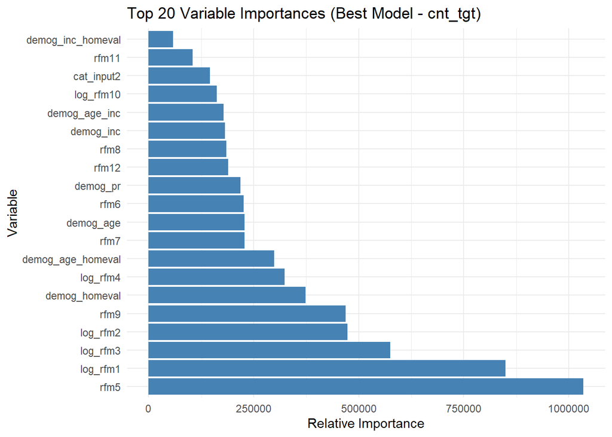

```r
# Get variable importance for the best model
varimp_df_cnt <- as.data.frame(h2o.varimp(best_model_cnt))

# Plot top 20 variable importances using ggplot2
ggplot(varimp_df_cnt[1:20, ], aes(x = reorder(variable, -relative_importance), y = relative_importance)) +
  geom_bar(stat = "identity", fill = "steelblue") +
  coord_flip() +
  labs(title = "Top 20 Variable Importances (Best Model - cnt_tgt)",
       x = "Variable",
       y = "Relative Importance") +
  theme_minimal()
```

```r
# Predicted vs Actual plot for the best model
predicted_cnt <- h2o.predict(best_model_cnt, newdata = test)
```

```
##   |                                                                              |                                                                      |   0%  |                                                                              |=========================================================…
```

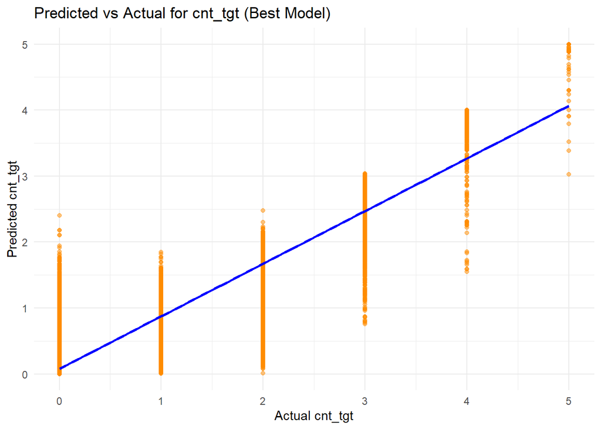

```r
predicted_cnt_df <- as.data.frame(predicted_cnt)
predicted_cnt_df$actual <- as.data.frame(test)$cnt_tgt
predicted_cnt_df$actual <- as.numeric(predicted_cnt_df$actual)
predicted_cnt_df$predicted <- as.numeric(predicted_cnt_df$predict)

ggplot(predicted_cnt_df, aes(x = actual, y = predicted)) +
  geom_point(alpha = 0.5, color = "darkorange") +
  geom_smooth(method = "lm", color = "blue") +
  labs(title = "Predicted vs Actual for cnt_tgt (Best Model)",
       x = "Actual cnt_tgt",
       y = "Predicted cnt_tgt") +
  theme_minimal()
```

```r
# Inspect GLM coefficients if the 4th model is GLM
model_4_cnt <- h2o.getModel(top_models_cnt[4])
if (model_4_cnt@algorithm == "glm") {
  # Extract the full coefficient table
  coef_table_cnt <- model_4_cnt@model$coefficients_table

  # Keep relevant columns and calculate odds ratio percentage
  coef_df_cnt <- coef_table_cnt[, c("names", "coefficients")]
  coef_df_cnt$Odds_Ratio_Percent <- round((exp(coef_df_cnt$coefficients) - 1) * 100, 2)

  # Rename columns for clarity
  colnames(coef_df_cnt) <- c("Predictor", "Coefficient", "Odds Ratio (%)")

  # Display table
  kable(coef_df_cnt, caption = "GLM Coefficients and Odds Ratios (%) for cnt_tgt") %>%
    kable_styling(full_width = FALSE, position = "left") %>%
    column_spec(1, bold = TRUE) %>%
    column_spec(2, color = "blue") %>%
    column_spec(3, color = "red")

} else {
  cat("The 4th model is not a GLM. It is a", model_4_cnt@algorithm, "model.\n")
}
```

GLM Coefficients and Odds Ratios (%) for cnt_tgt

| Predictor | Coefficient | Odds Ratio (%) |
| --- | --- | --- |
| Intercept | 1.5087728 | 352.12 |
| cat_input2.A | 0.0181896 | 1.84 |
| cat_input2.B | 0.0232440 | 2.35 |
| cat_input2.C | -0.0044892 | -0.45 |
| cat_input2.D | -0.0100478 | -1.00 |
| cat_input2.E | -0.0272705 | -2.69 |
| cat_input1.X | -0.0171031 | -1.70 |
| cat_input1.Y | -0.0281818 | -2.78 |
| cat_input1.Z | 0.0487102 | 4.99 |
| demog_genf.0 | 0.0003223 | 0.03 |
| demog_genf.1 | 0.0023244 | 0.23 |
| demog_age | -0.0009596 | -0.10 |
| demog_ho | -0.0055315 | -0.55 |
| demog_homeval | 0.0000013 | 0.00 |
| demog_inc | 0.0000004 | 0.00 |
| demog_pr | -0.0003986 | -0.04 |
| rfm5 | 0.1519339 | 16.41 |
| rfm6 | 0.0021239 | 0.21 |
| rfm7 | -0.0164522 | -1.63 |
| rfm8 | 0.0029292 | 0.29 |
| rfm9 | -0.0364782 | -3.58 |
| rfm11 | -0.0255904 | -2.53 |
| rfm12 | -0.0001056 | -0.01 |
| log_rfm1 | -0.1606913 | -14.84 |
| log_rfm2 | -0.1890883 | -17.23 |
| log_rfm3 | 0.0418248 | 4.27 |
| log_rfm4 | -0.0147741 | -1.47 |
| log_rfm10 | -0.0331659 | -3.26 |
| demog_inc_homeval | 0.0000000 | 0.00 |
| demog_age_homeval | 0.0000000 | 0.00 |
| demog_age_inc | 0.0000000 | 0.00 |